# Peruvian women’s knowledge and attitudes concerning Tuberculosis

Findings from the 2018 Demographic and Health Survey

Cusi Ferradas

Jan 10, 2023

The Demographic and Health Survey (DHS) are nationally-representative household surveys conducted in different countries. For the present report, the DHS women’s survey conducted in Peru was analyzed to describe their knowledge and attitudes about Tuberculosis (TB). This survey was conducted in the 24 departments of the country and the “Provincia constitucional del Callao.”

The survey was answered by 23,888 Peruvian women between 15 and 49 years old.

# Have heard about tuberculosis

Of all Peruvian women included in the survey, 93.3% have heard about tuberculosis (Table 1 and Figure 1).

| Heard about TB | Number | Percent |
| --- | --- | --- |
| no | 1,606 | 6.7% |
| yes | 22,282 | 93.3% |
| Total | 23,888 | - |

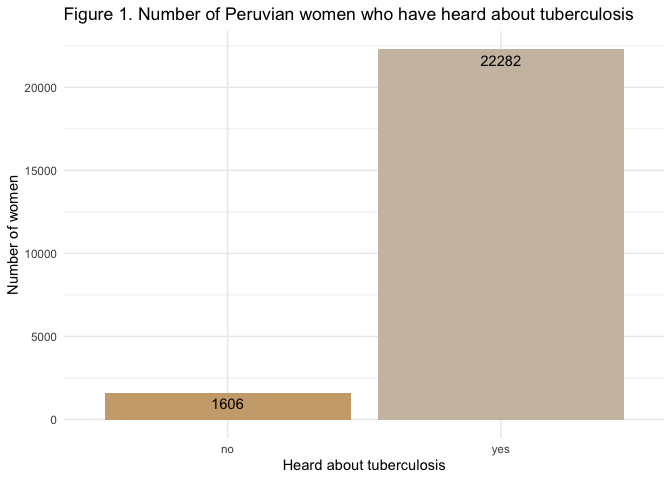

## Have heard about TB according to their educational level in six different departments of Peru.

For this analysis, six departments of the country are shown, two from the coast (Lima and Arequipa), two from the highlands (Ancash and Apurimac), and two from the rain forest (Amazonas and Loreto).

The percentage of people who have heard about tuberculosis increases as the level of education increases (Figure 2). This increase is more noticeable between the group who has received no education and those who have finished primary education, especially in Arequipa where only 36% of women with no education have heard about TB, while 82% of women with primary education had.

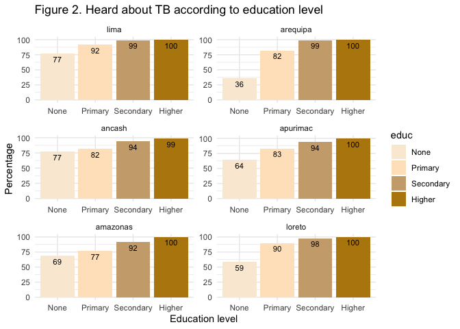

## Median age of people who have heard and have not heard about TB in six different regions of Peru.

| region | heard_tb | median_age |
| --- | --- | --- |
| lima | no | 26 |
| lima | yes | 31 |
| arequipa | no | 28.5 |
| arequipa | yes | 32 |
| ancash | no | 25.5 |
| ancash | yes | 31 |
| apurimac | no | 33 |
| apurimac | yes | 29.5 |
| amazonas | no | 25 |
| amazonas | yes | 31 |

[output cut: 2 more lines]

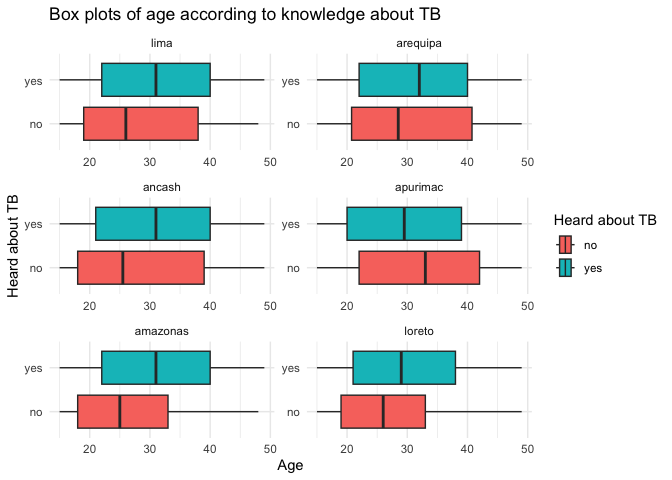

# TB will be kept as a secret

Women included in the survey answered the question “If a family member gets TB, would you keep it as a secret.” More than 40% of women living in urban and rural areas said that they would keep their family member’s diagnosis of TB as a secret. This may be because of negative social attitudes, like stigmatization against people with this disease in some communities, as has been reported previously in other countries (Dodor, 2012; Armijos et al.,2008).

[output not shown]

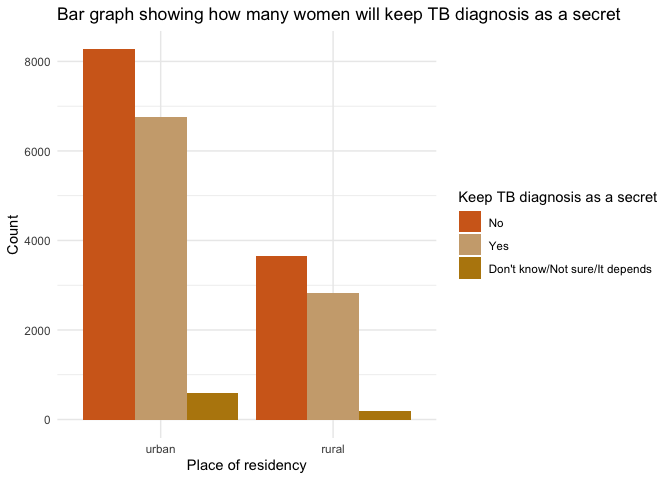